# PCA and Clustering Analysis on Car Sales

Giovanni Del Piano

2025-05-02

# 1 Introduzione

# 2 Cos’è la PCA?

La **Principal Component Analysis** è una tecnica non supervisionata usata per ridurre la dimensionalità di un dataset mantenendo la maggior parte della **varianza** dei dati originali.

### 2.0.1 Obiettivi principali della PCA:

- Ridurre il numero di variabili mantenendo l’informazione.
- Identificare nuove variabili (componenti principali) non correlate.
- Visualizzare dati complessi in 2D o 3D.

> La PCA proietta i dati su nuove direzioni (componenti principali) che spiegano la massima varianza, ordinate in modo decrescente.

# 3 Caricamento e Preprocessing del Dataset

```r
library(ggplot2)
library(FactoMineR)
library(factoextra)
library(corrplot)
library(PerformanceAnalytics)
library(readxl)
library(dplyr)
library(DescTools)

setwd("C:\\Users\\Windows 10\\OneDrive\\Desktop\\LUISS LESSON\\02 script\\data")
#upload the dataset
car_sales = read_excel("car_sales.xlsx", sheet='data')
```

## 3.1 DataFrame

```r
# DataFrame
head(car_sales)
```

```
## # A tibble: 6 × 15
##   Manufacturer Model   Sales Vehicle_type Price Engine_size Horsepower Wheelbase
##   <chr>        <chr>   <dbl> <chr>        <dbl>       <dbl>      <dbl>     <dbl>
## 1 Ford         F-Ser… 540561 Car          26935         4.6        220      138.
## 2 Ford         Explo… 276747 Car          31930         4          210      112.
## 3 Toyota       Camry  247994 Passenger    17518         2.2        133      105.
## 4 Ford         Taurus 245815 Passenger    17885         3          155      108.
## 5 Honda        Accord 230902 Passenger    15350         2.3        135      107.
## 6 Dodge        Ram P… 227061 Car          19460         5.2        230      139.
## # ℹ 7 more variables: Width <dbl>, Length <dbl>, Curb_weight <dbl>,
## #   Fuel_capacity <dbl>, Fuel_efficiency <dbl>, Latest_Launch <chr>,
## #   Nationality <chr>
```

## 3.2 Data Dictionary

| Variable | Description |
| --- | --- |
| Manufacturer | Nome del Brand |
| Model | Modello della macchina |
| Sales | Numero di vendite |
| Vehicle_type | Tipo di veicolo |
| Price | Prezzo del veicolo in dollari |
| Engine_size | Volume dei cilindri |
| Horsepower | Numero di cavalli |
| Wheelbase | Distanza degli assi |
| Width | Larghezza del veicolo |
| Length | Lunghezza del veicolo |
| Curb_weight | Peso del veicolo a secco |
| Fuel_capacity | Capacità di rifornimento |
| Fuel_efficiency | Fuel efficiency (gallon / miles) |
| Latest_launch | Data di lancio |
| Nationality | Paese del brand |

## 3.3 Summary

```r
# Summary
summary(car_sales)
```

```
##  Manufacturer          Model               Sales        Vehicle_type
##  Length:117         Length:117         Min.   :   110   Length:117
##  Class :character   Class :character   1st Qu.: 16767   Class :character
##  Mode  :character   Mode  :character   Median : 32299   Mode  :character
##                                        Mean   : 59112
##                                        3rd Qu.: 76029
##                                        Max.   :540561
##      Price        Engine_size      Horsepower      Wheelbase
##  Min.   : 9235   Min.   :1.000   Min.   : 55.0   Min.   : 92.6
##  1st Qu.:16980   1st Qu.:2.200   1st Qu.:140.0   1st Qu.:102.4
##  Median :21665   Median :3.000   Median :175.0   Median :107.0
##  Mean   :25969   Mean   :3.049   Mean   :181.3   Mean   :107.3
##  3rd Qu.:29465   3rd Qu.:3.800   3rd Qu.:210.0   3rd Qu.:111.6
##  Max.   :82600   Max.   :8.000   Max.   :450.0   Max.   :138.7
##      Width           Length       Curb_weight    Fuel_capacity
##  Min.   :62.60   Min.   :149.4   Min.   :1.895   Min.   :10.30
##  1st Qu.:68.50   1st Qu.:177.5   1st Qu.:2.911   1st Qu.:15.30
##  Median :70.40   Median :187.8   Median :3.340   Median :17.20
##  Mean   :71.19   Mean   :187.7   Mean   :3.324   Mean   :17.81
##  3rd Qu.:73.60   3rd Qu.:196.5   3rd Qu.:3.823   3rd Qu.:19.80
##  Max.   :79.30   Max.   :224.5   Max.   :5.115   Max.   :32.00
##  Fuel_efficiency Latest_Launch      Nationality
##  Min.   :15.00   Length:117         Length:117
##  1st Qu.:22.00   Class :character   Class :character
##  Median :24.00   Mode  :character   Mode  :character
##  Mean   :24.12
##  3rd Qu.:26.00
##  Max.   :45.00
```

## 3.4 Glimpse

```r
# Glimpse
glimpse(car_sales)
```

```
## Rows: 117
## Columns: 15
## $ Manufacturer    <chr> "Ford", "Ford", "Toyota", "Ford", "Honda", "Dodge", "F…
## $ Model           <chr> "F-Series", "Explorer", "Camry", "Taurus", "Accord", "…
## $ Sales           <dbl> 540561, 276747, 247994, 245815, 230902, 227061, 220650…
## $ Vehicle_type    <chr> "Car", "Car", "Passenger", "Passenger", "Passenger", "…
## $ Price           <dbl> 26935, 31930, 17518, 17885, 15350, 19460, 12050, 12885…
## $ Engine_size     <dbl> 4.6, 4.0, 2.2, 3.0, 2.3, 5.2, 2.5, 1.6, 2.4, 4.0, 3.0,…
## $ Horsepower      <dbl> 220, 210, 133, 155, 135, 230, 119, 106, 150, 195, 150,…
## $ Wheelbase       <dbl> 138.5, 111.6, 105.2, 108.5, 106.9, 138.7, 117.5, 103.2…
## $ Width           <dbl> 79.1, 70.2, 70.1, 73.0, 70.3, 79.3, 69.4, 67.1, 76.8, …
## $ Length          <dbl> 224.5, 190.7, 188.5, 197.6, 188.8, 224.2, 200.7, 175.1…
## $ Curb_weight     <dbl> 4.241, 3.876, 2.998, 3.368, 2.932, 4.470, 3.086, 2.339…
## $ Fuel_capacity   <dbl> 25.1, 21.0, 18.5, 16.0, 17.1, 26.0, 20.0, 11.9, 20.0, …
## $ Fuel_efficiency <dbl> 18, 19, 27, 24, 27, 17, 23, 32, 24, 19, 21, 27, 33, 25…
## $ Latest_Launch   <chr> "8/16/2012", "4/25/2012", "2/10/2011", "12/20/2011", "…
## $ Nationality     <chr> "USA", "USA", "Japan", "USA", "Japan", "USA", "USA", "…
```

```r
summary(car_sales$Price)
```

```
##    Min. 1st Qu.  Median    Mean 3rd Qu.    Max.
##    9235   16980   21665   25969   29465   82600
```

## 3.5 Structure

```r
# Let' add a Price Level feature

car_sales$Price_level = case_when(
  car_sales$Price<=15000 ~ "Low",
  car_sales$Price<=30000 ~ "Medium",
  car_sales$Price<=55000 ~ "Medium_High",
  TRUE ~ "High"
)

# Structure
str(car_sales)
```

```
## tibble [117 × 16] (S3: tbl_df/tbl/data.frame)
##  $ Manufacturer   : chr [1:117] "Ford" "Ford" "Toyota" "Ford" ...
##  $ Model          : chr [1:117] "F-Series" "Explorer" "Camry" "Taurus" ...
##  $ Sales          : num [1:117] 540561 276747 247994 245815 230902 ...
##  $ Vehicle_type   : chr [1:117] "Car" "Car" "Passenger" "Passenger" ...
##  $ Price          : num [1:117] 26935 31930 17518 17885 15350 ...
##  $ Engine_size    : num [1:117] 4.6 4 2.2 3 2.3 5.2 2.5 1.6 2.4 4 ...
##  $ Horsepower     : num [1:117] 220 210 133 155 135 230 119 106 150 195 ...
##  $ Wheelbase      : num [1:117] 138 112 105 108 107 ...
##  $ Width          : num [1:117] 79.1 70.2 70.1 73 70.3 79.3 69.4 67.1 76.8 72.3 ...
##  $ Length         : num [1:117] 224 191 188 198 189 ...
##  $ Curb_weight    : num [1:117] 4.24 3.88 3 3.37 2.93 ...
##  $ Fuel_capacity  : num [1:117] 25.1 21 18.5 16 17.1 26 20 11.9 20 20.5 ...
##  $ Fuel_efficiency: num [1:117] 18 19 27 24 27 17 23 32 24 19 ...
##  $ Latest_Launch  : chr [1:117] "8/16/2012" "4/25/2012" "2/10/2011" "12/20/2011" ...
##  $ Nationality    : chr [1:117] "USA" "USA" "Japan" "USA" ...
##  $ Price_level    : chr [1:117] "Medium" "Medium_High" "Medium" "Medium" ...
```

# 4 Data Exploration

Esploriamo il dato constatando distribuzioni delle variabili e correlazioni

## 4.1 Pair Plot

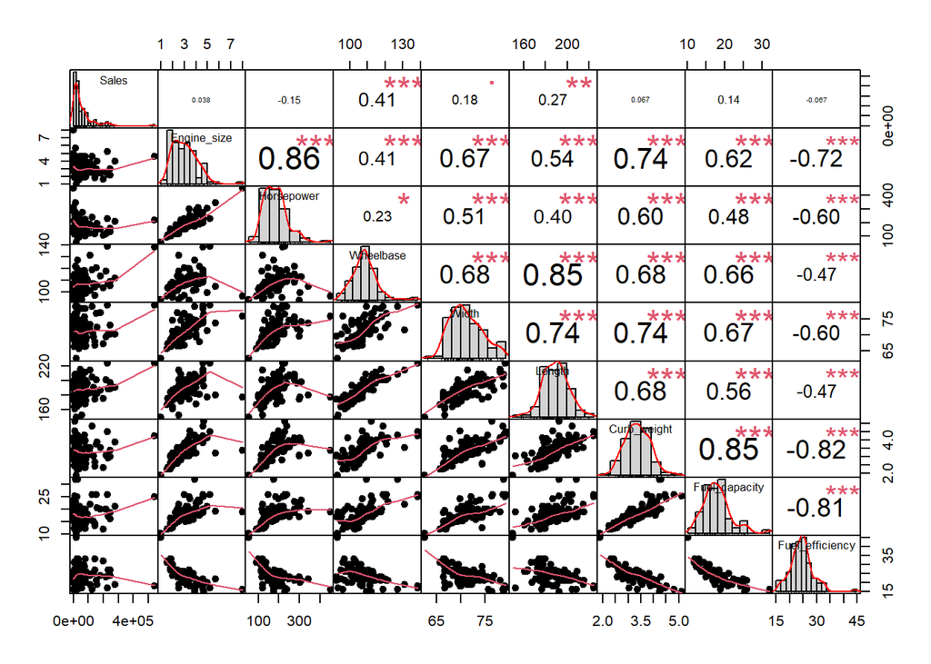

```r
# Selecting numerical variables
car_sales_num = car_sales %>% select_if(is.numeric) %>% select(-"Price")
rownames(car_sales_num) = car_sales$Manufacter_Model
rownames(car_sales) = car_sales$Manufacter_Model
# plot distributions and correlations for each pair of variables
chart.Correlation(car_sales_num, histogram=TRUE, pch=19)
```

## 4.2 Correlation Plot

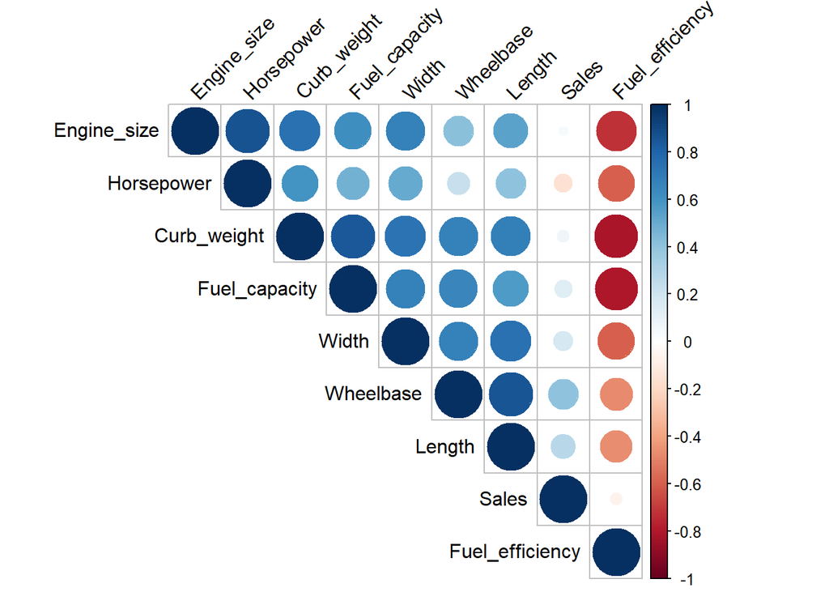

```r
corrplot(cor(car_sales_num), type="upper", order="hclust", tl.col="black", tl.srt=45)
```

## 4.3 Distribution Plot

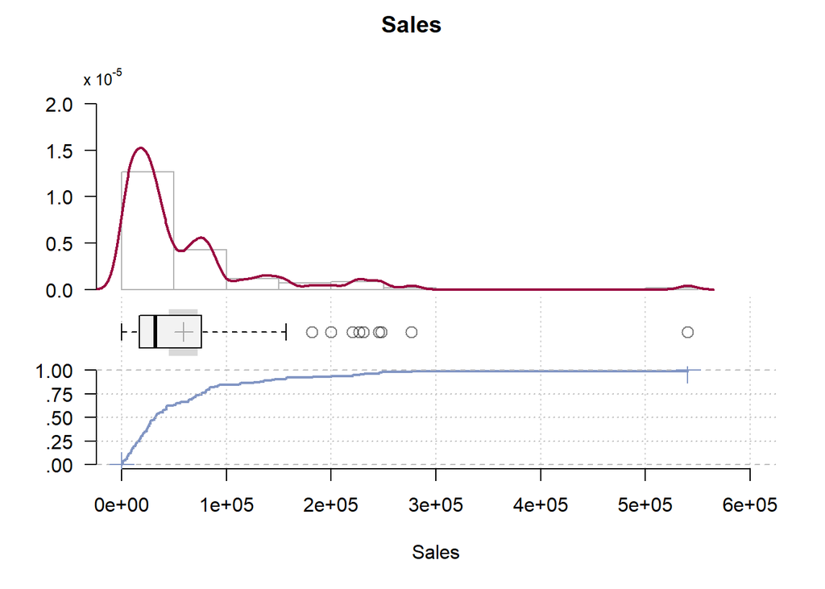

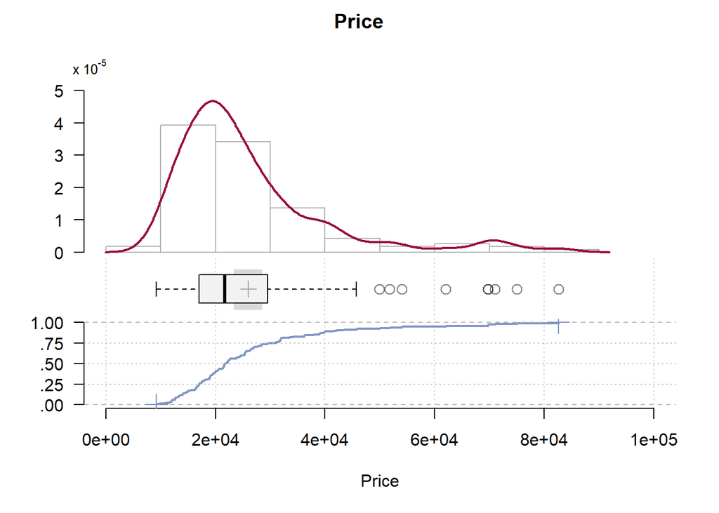

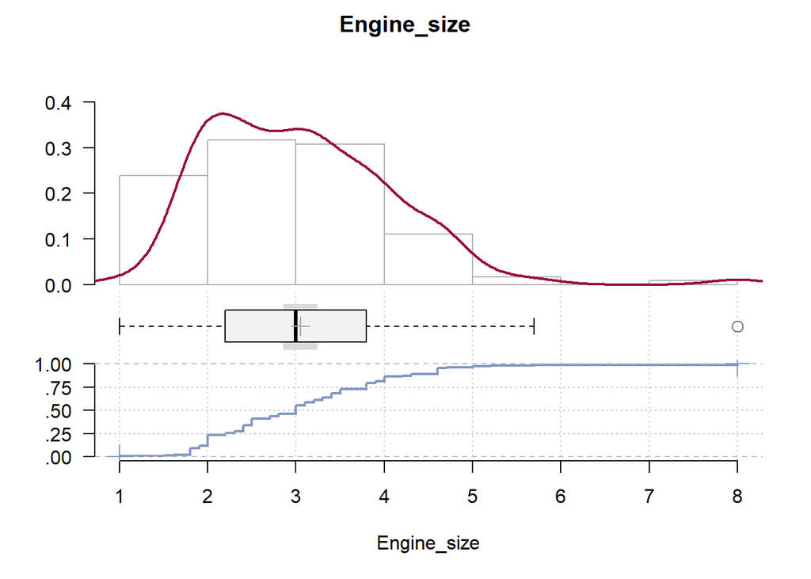

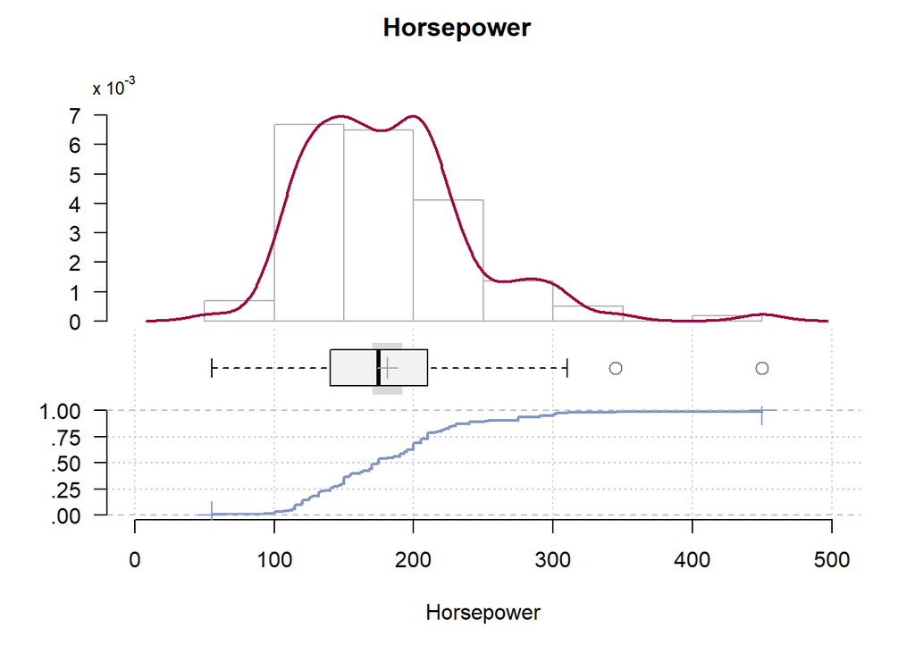

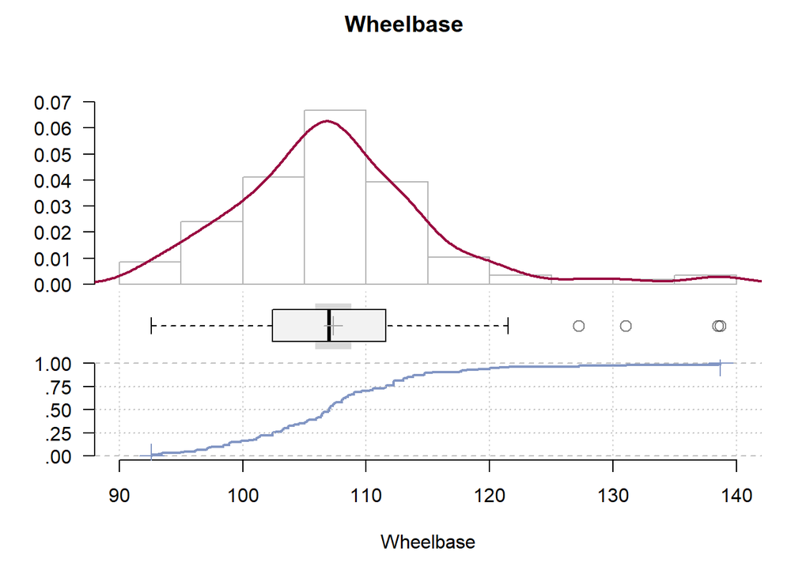

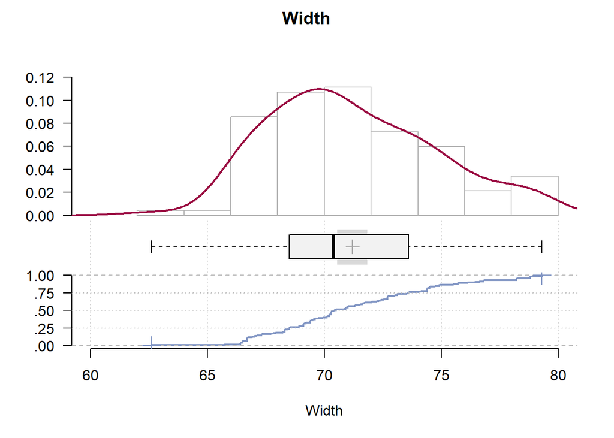

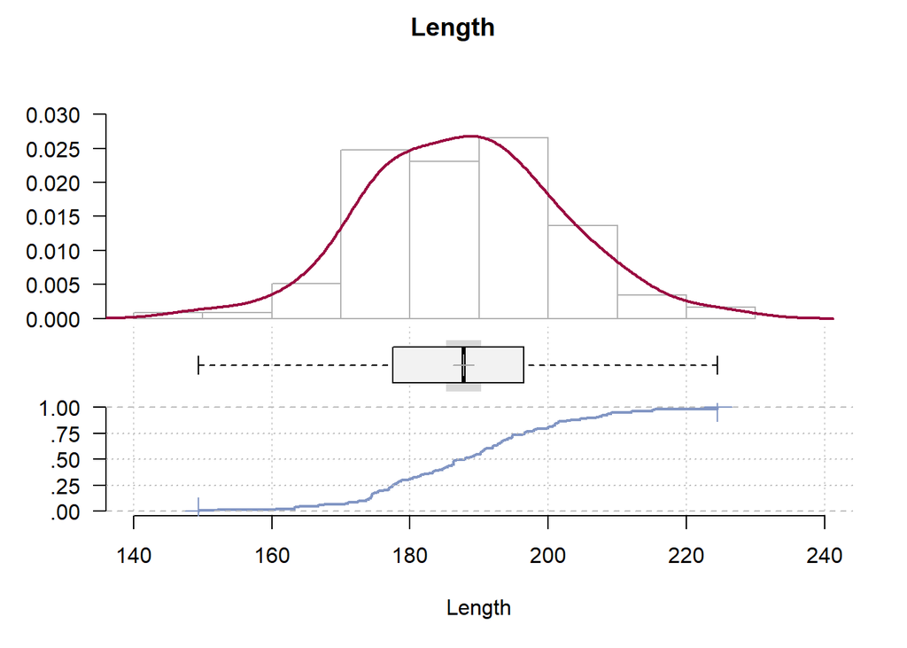

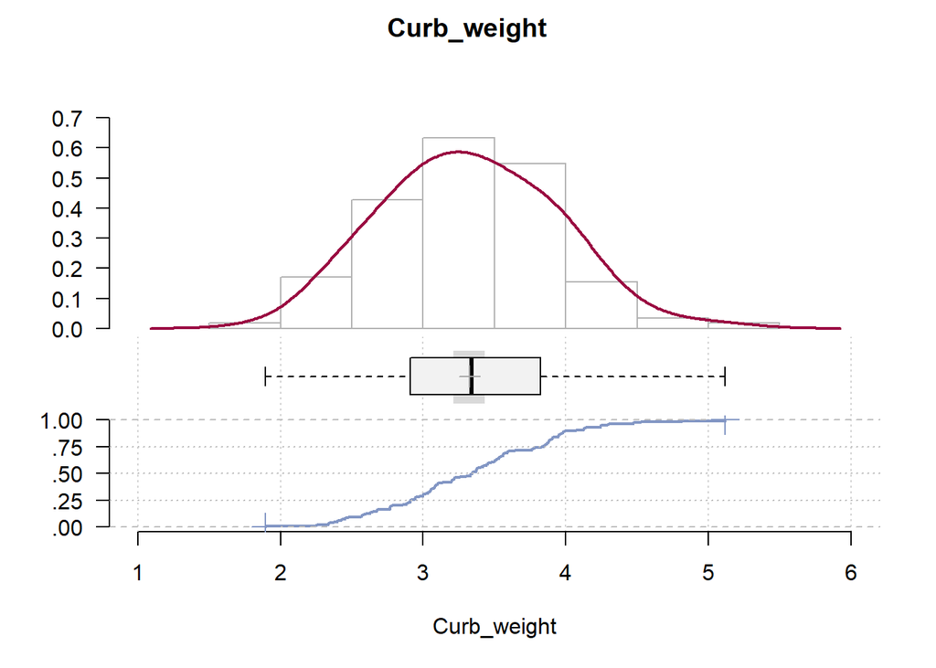

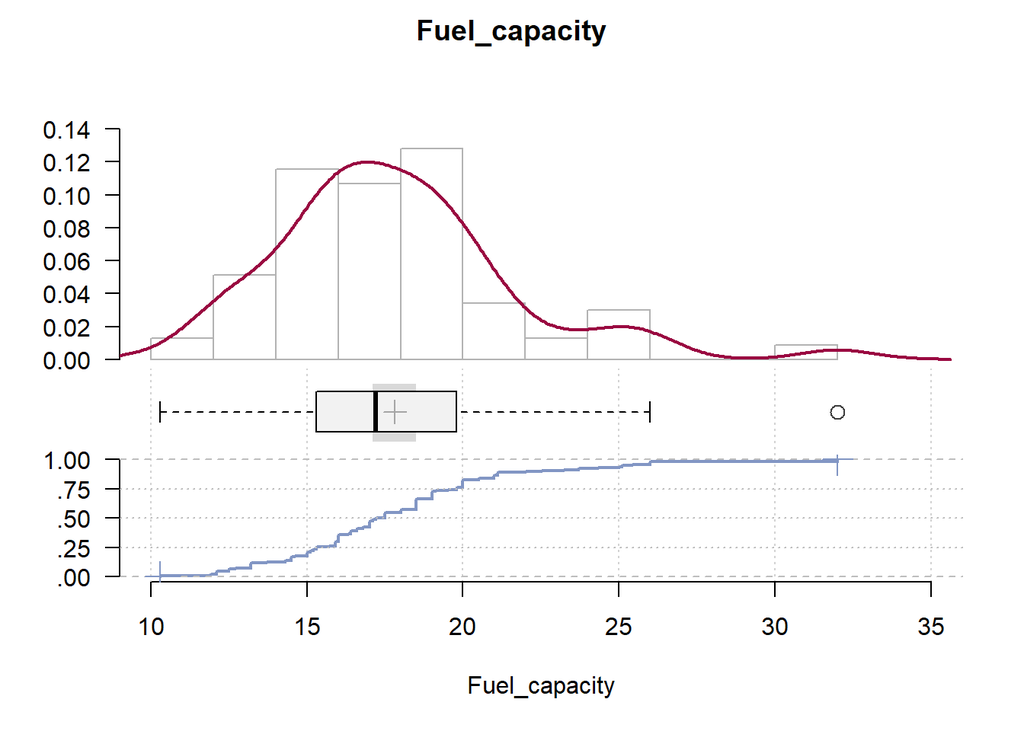

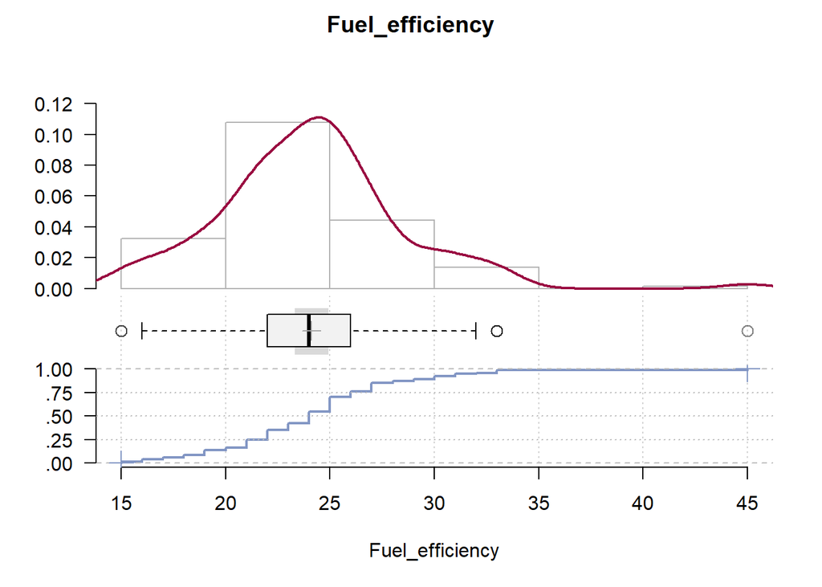

```r
for (col in colnames(car_sales)) {
  if (is.numeric(car_sales[[col]])) {
    PlotFdist(car_sales[[col]], main = col, xlab = col)
  }
}
```

Come mostrato di seguito, esiste una **forte correlazione positiva** tra le variabili quantitative che descrivono le caratteristiche meccaniche, come le dimensioni, la potenza del motore e la capacità del serbatoio. Come ci si potrebbe aspettare, queste variabili sono negativamente correlate con l’efficienza del carburante.

Per quanto riguarda la variabile che descrive il numero di vendite, si osserva che presenta basse correlazioni con le altre variabili quantitative, ad eccezione della variabile “Wheelbase”, per la quale il coefficiente di correlazione è pari a 0.4.

# 5 PCA ANALYSIS

```r
# PCA con centering e scaling
pca <- prcomp(car_sales_num, center = TRUE, scale. = TRUE)

# Sommario dei componenti
summary(pca)
```

```
## Importance of components:
##                           PC1    PC2     PC3     PC4     PC5     PC6     PC7
## Standard deviation     2.3397 1.2259 0.80964 0.79220 0.52582 0.41196 0.34627
## Proportion of Variance 0.6082 0.1670 0.07284 0.06973 0.03072 0.01886 0.01332
## Cumulative Proportion  0.6082 0.7752 0.84806 0.91779 0.94851 0.96736 0.98069
##                            PC8     PC9
## Standard deviation     0.30704 0.28203
## Proportion of Variance 0.01048 0.00884
## Cumulative Proportion  0.99116 1.00000
```

## 5.1 Scree Plot

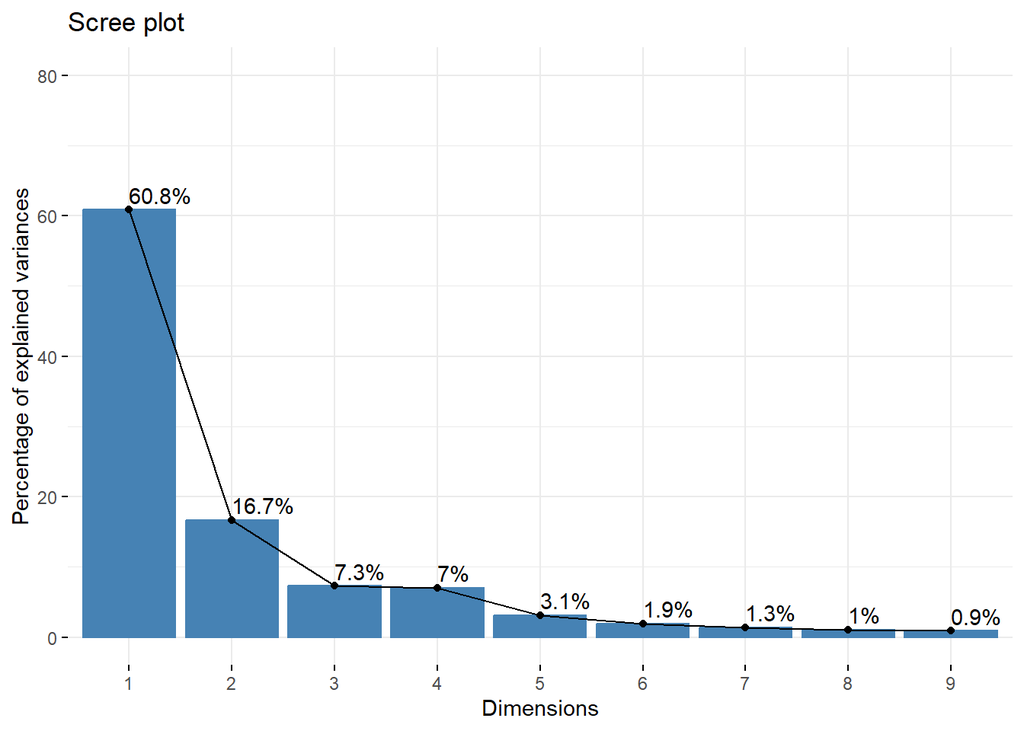

```r
fviz_eig(pca, addlabels = TRUE, ylim = c(0, 80))
```

Il grafico mostra quanta varianza spiega ciascuna componente. Le prime 2 o 3 componenti spesso sono sufficienti per rappresentare i dati.

Osservando gli autovalori, le prime due dimensioni contengono il 78% dell’inerzia totale (varianza). Questa percentuale è accettabile per mantenere i primi due assi principali per il resto della nostra analisi, anche in base alla “Regola di Kaiser”.

## 5.2 Interpretazione delle componenti

### 5.2.1 PCA Biplot

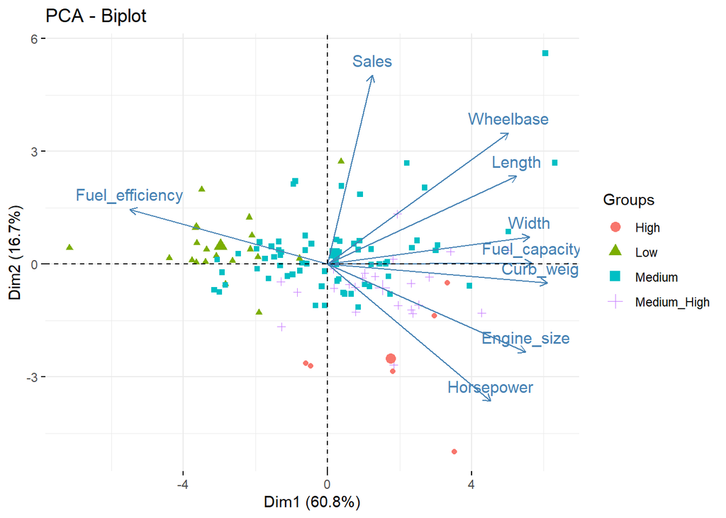

```r
# Change of the cartesian system
pca$rotation=-pca$rotation
pca$x=-pca$x



# Biplot with price level labels
fviz_pca_biplot(pca, label = "var", habillage=car_sales$Price_level)
```

### 5.2.2 Cos2: Quality of the variabes on the factor map

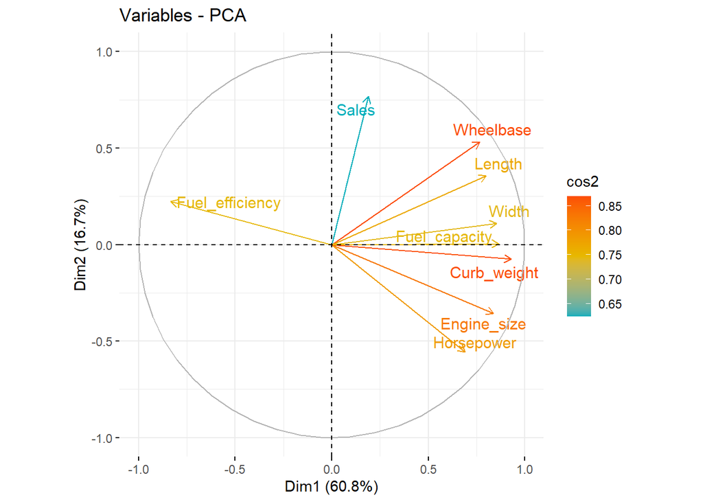

```r
# Graph of variables (cos2 = the quality of the variables on the factor map)
fviz_pca_var(pca, col.var = "cos2",
             gradient.cols = c("#00AFBB", "#E7B800", "#FC4E07"),
             repel = TRUE)
```

### 5.2.3 Corrplot with Dimensions

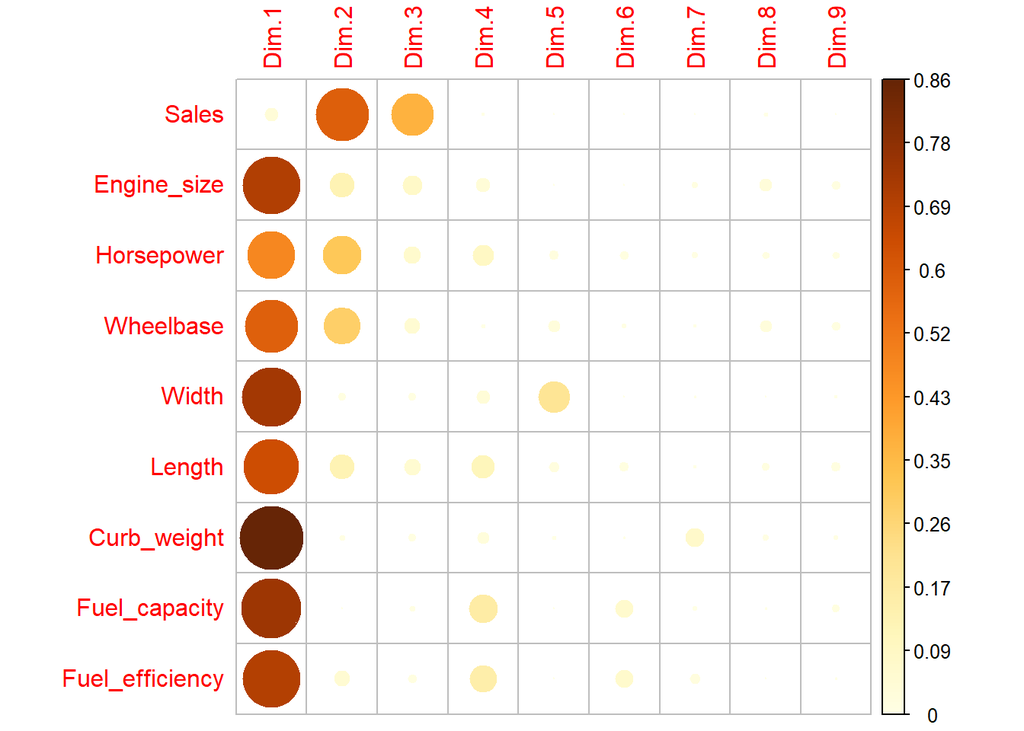

```r
var1 = get_pca_var( pca)
# var$cos2: represents the quality of representation for variables on the factor
# map. It's calculated as the squared coordinates: var$cos2 = var$coord ^2

corrplot(var1$cos2, is.corr=FALSE)
```

Un cos2 elevato indica una buona rappresentazione della variabile sulla componente principale. In questo caso la variabile è posizionata vicino alla circonferenza del cerchio di correlazione.

Il grafico mostra che le variabili “Engine_size” e ‘Horse_power’ sono correlate negativamente con la variabile “Fuel_efficiency”.

Questi risultati sembrano abbastanza logici, perché quanto più grande e potente è un motore, tanto più alto sarà il suo consumo. Pertanto, l’efficienza energetica sarà bassa (valore elevato in litri/km o galloni/miglia).

La variabile “Sales” non è molto correlata con le variabili ‘Horse_power’, “Engine_size” e “Fuel_Efficiency”.

# 6 Cos’è il Clustering Non Gerarchico?

Il **clustering** è una tecnica non supervisionata per raggruppare osservazioni simili. Il metodo **k-means** è tra i più usati:

## 6.1 Come funziona k-means:

1. Scegliere il numero di cluster $k$.
2. Inizializzare casualmente $k$ centroidi.
3. Assegnare ciascun punto al centroide più vicino.
4. Aggiornare i centroidi come media dei punti assegnati.
5. Ripetere fino a convergenza.

> Il clustering è utile per scoprire **pattern latenti** nei dati.

## 6.2 Determinare il numero ottimale di cluster

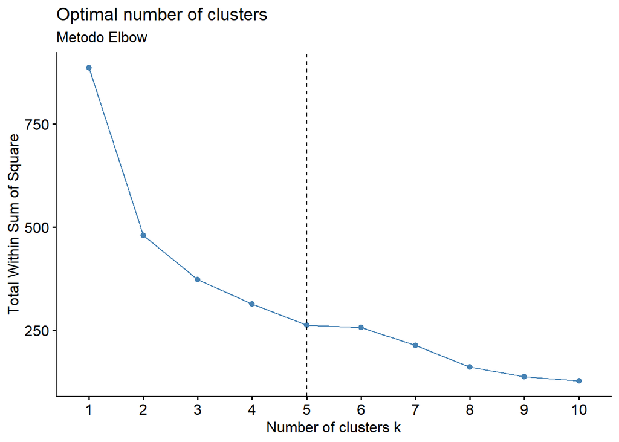

```r
fviz_nbclust(pca$x[, 1:3], kmeans, method = "wss") +
  geom_vline(xintercept = 5, linetype = 2) +
  labs(subtitle = "Metodo Elbow")
```

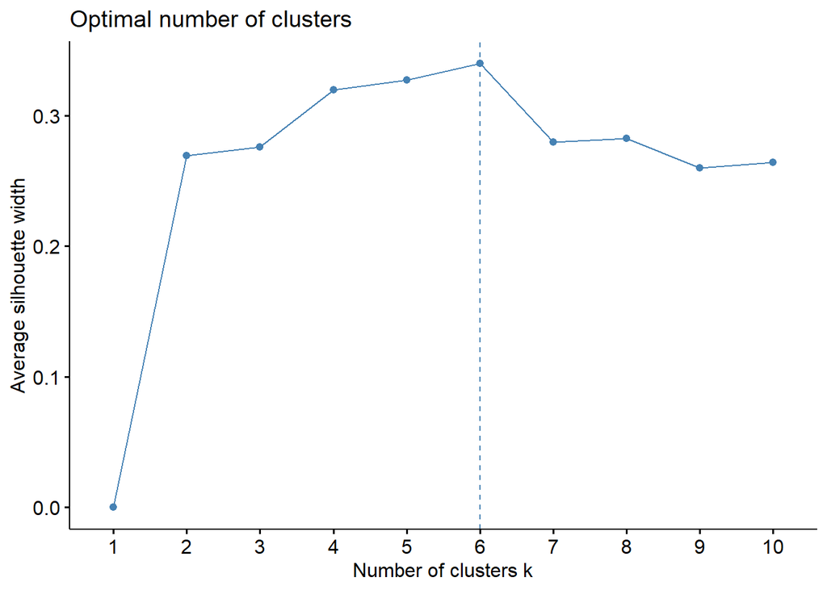

```r
pca$x[, 1:3] %>%
  scale() %>%
  fviz_nbclust(FUN = hcut, method = 'silhouette')
```

## 6.3 Clustering k-means

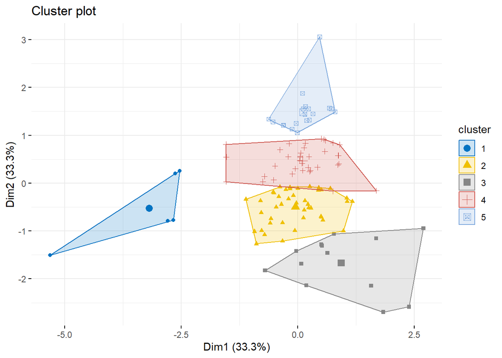

```r
set.seed(123)
kmeans_res <- kmeans(pca$x[, 1:3], centers = 5, nstart = 15)

# Visualizzazione
fviz_cluster(kmeans_res, data = pca$x[, 1:3],
             geom = "point",
             palette = "jco",
             ggtheme = theme_minimal())
```

## 6.4 Confronto con i gruppi reali

```r
table(Cluster = kmeans_res$cluster, Prezzo = car_sales$Price_level)
```

```
##        Prezzo
## Cluster High Low Medium Medium_High
##       1    4   0      0           1
##       2    1   0     26          16
##       3    1   0      9           3
##       4    0   7     27           3
##       5    0  13      6           0
```

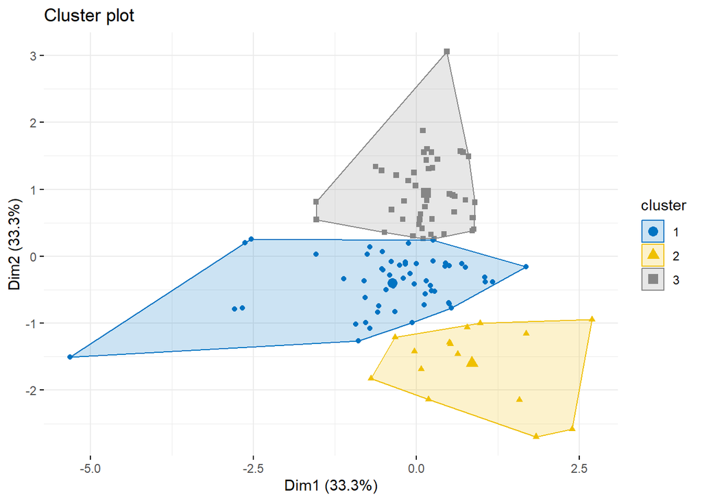

```r
kmeans_res <- kmeans(pca$x[, 1:3], centers = 3, nstart = 50)

# Visualizzazione
fviz_cluster(kmeans_res, data = pca$x[, 1:3],
             geom = "point",
             palette = "jco",
             ggtheme = theme_minimal())
```

```r
# Let' add a Price Level feature

car_sales$Price_level = case_when(
  car_sales$Price<=25000 ~ "Low",
  car_sales$Price<=35000 ~ "Medium",
  TRUE ~ "High"
)
```

```r
table(Cluster = kmeans_res$cluster, Prezzo = car_sales$Price_level)
```

```
##        Prezzo
## Cluster High Low Medium
##       1   14  19     21
##       2    5   7      3
##       3    1  45      2
```

## 6.5 Conclusioni

- La PCA consente di ridurre la dimensionalità dei dati preservandone l’informazione più importante.
- Il clustering non supervisionato può individuare strutture latenti nei dati.
- La combinazione di PCA + k-means è molto potente per esplorare dataset complessi.